# Supplemental Materials

The association between crashes and safety-critical events: synthesized evidence from crash reports and naturalistic driving data among commercial truck drivers.

Author names anonymized for peer-review

2019-10-14

# 1 Ping data and trip aggregation

## 1.1 Ping data demonstration

```r
pacman::p_load(data.table, dplyr, ggplot2, lubridate, kableExtra)
d = fread("data/sample_ping.csv") %>%
  .[,ping_time := ymd_hms(ping_time)]

knitr::kable(d[1:10,], align = "c", caption = "Sample ping data")
```

Sample ping data

| driver | ping_time | speed | lat | long |
| --- | --- | --- | --- | --- |
| sample_driver | 2014-01-23 23:00:12 | 0 | 35.37409 | -77.92632 |
| sample_driver | 2014-01-23 23:15:12 | 0 | 35.37410 | -77.92639 |
| sample_driver | 2014-01-23 23:16:40 | 0 | 35.37409 | -77.92639 |
| sample_driver | 2014-01-23 23:18:38 | 0 | 35.37410 | -77.92638 |
| sample_driver | 2014-01-23 23:21:00 | 12 | 35.37359 | -77.92545 |
| sample_driver | 2014-01-23 23:24:08 | 54 | 35.38403 | -77.93978 |
| sample_driver | 2014-01-23 23:30:00 | 56 | 35.40838 | -78.00330 |
| sample_driver | 2014-01-23 23:30:12 | 58 | 35.41101 | -78.00227 |
| sample_driver | 2014-01-23 23:30:28 | 1 | 35.41340 | -78.00162 |
| sample_driver | 2014-01-23 23:37:14 | 23 | 35.41419 | -78.00145 |

The above table shows a sample of the original data. It includes the exact date and time of the record (year, month, day, hour, minute, and second), latitude and longitude (specific to five decimal places), speed, and drivers’ anonymized unique ID.

## 1.2 Aggregating ping data into trips

The self-defined function `segment_0()` below is used to separate the original ping data into trips according to a threshold value.

```r
segment_0 = function(speed, threshold, time_diff) {
  speed1 = speed
  speed[time_diff >= threshold] <- 0
  r1 = rle(speed != 0)
  r1$values <- replicate(length(r1$values), 1)
  r1$values <- cumsum(r1$values)
  order_tmp <- inverse.rle(r1)
  dat_tmp1 <- data.table::data.table(speed, order_tmp, time_diff)
  dat_tmp2 <- dat_tmp1[,.(sumdiff = sum(time_diff)), by = order_tmp]
  r2 = rle(speed != 0); first_rle = r2$values[1]
  r2$values[r2$values == 0 & dat_tmp2$sumdiff < threshold] <- TRUE
  r2$values[1] = first_rle
  r2 <- rle(inverse.rle(r2))
  r2$values[r2$values] = cumsum(r2$values[r2$values])
  id = inverse.rle(r2)
  jump_speed = which(id == 0 & speed1 != 0)
  id[jump_speed] = id[jump_speed + 1]
  return(id)
}
```

The code block below shows R code to separate the original ping data into different trips by adding a `trip_id` column. Here we set the threshold value as 30 minutes, which means that the ping data will be separated into different trips when the vehicle is not moving (the speed of the ping equals zero) for more than 30 minutes. The pings that has `trip_id` of 0 are stopping pings.

```r
d_id = d %>%
  .[,diff := as.integer(difftime(ping_time, shift(ping_time, type = "lag", fill = 0),
                                 units = "mins")), driver] %>%
  .[,diff := {diff[1] = 0L; diff}, driver] %>%
  .[,trip_id := segment_0(speed = speed, threshold = 30, time_diff = diff), driver]

knitr::kable(d_id[1:10,], align = "c", caption = "Sample ping data with time difference and trip ID")
```

Sample ping data with time difference and trip ID

| driver | ping_time | speed | lat | long | diff | trip_id |
| --- | --- | --- | --- | --- | --- | --- |
| sample_driver | 2014-01-23 23:00:12 | 0 | 35.37409 | -77.92632 | 0 | 0 |
| sample_driver | 2014-01-23 23:15:12 | 0 | 35.37410 | -77.92639 | 15 | 0 |
| sample_driver | 2014-01-23 23:16:40 | 0 | 35.37409 | -77.92639 | 1 | 0 |
| sample_driver | 2014-01-23 23:18:38 | 0 | 35.37410 | -77.92638 | 1 | 0 |
| sample_driver | 2014-01-23 23:21:00 | 12 | 35.37359 | -77.92545 | 2 | 1 |
| sample_driver | 2014-01-23 23:24:08 | 54 | 35.38403 | -77.93978 | 3 | 1 |
| sample_driver | 2014-01-23 23:30:00 | 56 | 35.40838 | -78.00330 | 5 | 1 |
| sample_driver | 2014-01-23 23:30:12 | 58 | 35.41101 | -78.00227 | 0 | 1 |
| sample_driver | 2014-01-23 23:30:28 | 1 | 35.41340 | -78.00162 | 0 | 1 |
| sample_driver | 2014-01-23 23:37:14 | 23 | 35.41419 | -78.00145 | 6 | 1 |

The table below is the aggregated trips data, including start time, end time, trip length, and the median trip time. The ping table and trips table can be merged into one table using driver ID and trip ID.

```r
d_trip = d %>%
  .[trip_id != 0,] %>%
  .[,.(start_time = ping_time[1], end_time = ping_time[.N]), .(driver, trip_id)] %>%
  .[,trip_length := round(as.numeric(difftime(end_time, start_time, units = "mins")), 2)] %>%
  .[,trip_median := start_time + 60*trip_length/2]

knitr::kable(d_trip, align = "c", caption = "Aggregated trips from sample ping")
```

Aggregated trips from sample ping

| driver | trip_id | start_time | end_time | trip_length | trip_median |
| --- | --- | --- | --- | --- | --- |
| sample_driver | 1 | 2014-01-23 23:21:00 | 2014-01-24 07:45:58 | 504.97 | 2014-01-24 03:33:29 |
| sample_driver | 2 | 2014-01-24 08:54:08 | 2014-01-24 12:26:26 | 212.30 | 2014-01-24 10:40:17 |
| sample_driver | 3 | 2014-01-24 23:06:20 | 2014-01-25 00:04:54 | 58.57 | 2014-01-24 23:35:37 |
| sample_driver | 4 | 2014-01-25 01:15:12 | 2014-01-25 02:00:14 | 45.03 | 2014-01-25 01:37:42 |
| sample_driver | 5 | 2014-01-25 04:21:36 | 2014-01-25 05:32:48 | 71.20 | 2014-01-25 04:57:12 |
| sample_driver | 6 | 2014-01-25 08:13:24 | 2014-01-25 12:45:10 | 271.77 | 2014-01-25 10:29:17 |

## 1.3 Ping and trip data visualization

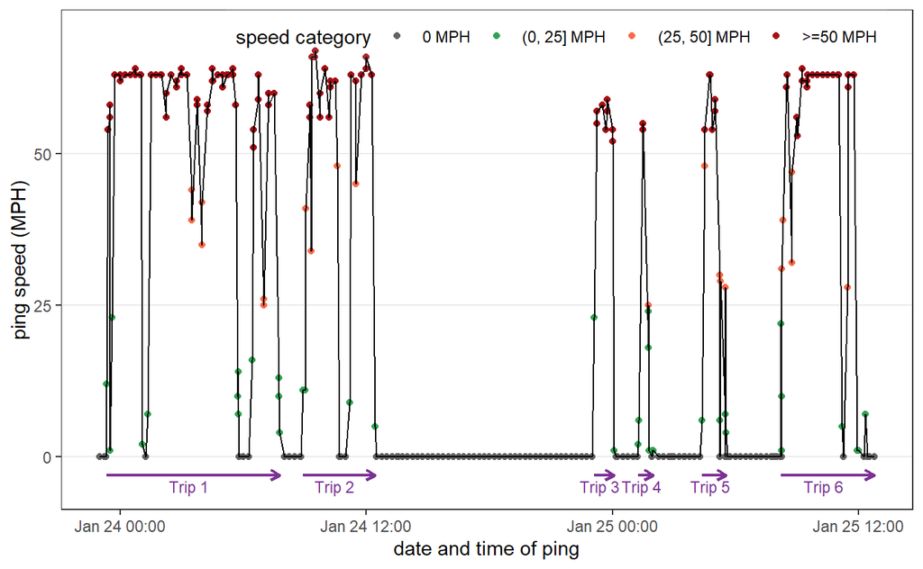

```r
p2 = d %>%
  .[,p_color := case_when(speed >= 50 ~ ">=50 MPH",
                             speed >= 25 & speed < 50 ~ "(25, 50] MPH",
                             speed >   0 & speed < 25 ~ "(0, 25] MPH",
                             speed == 0 ~ "0 MPH")] %>%
  .[,p_color := factor(p_color, levels = c("0 MPH", "(0, 25] MPH", "(25, 50] MPH", ">=50 MPH"))] %>%
  ggplot(aes(ping_time, speed)) +
  geom_point(aes(color = p_color)) +
  scale_colour_manual(name = "speed category", values = c("#636363", "#31a354", "#fb6a4a", "#a50f15")) +
  geom_line() + theme_bw() +
  geom_segment(data = d_trip, aes(x = start_time, xend = end_time, y = -3, yend = -3),
               arrow = arrow(length = unit(.2, "cm")), lineend = 'butt', size = .8, color = "#7b3294") +
  geom_text(data = d_trip, aes(x = trip_median, y = rep(-4.8, nrow(d_trip)),
                             label = paste(rep("Trip", nrow(d_trip)), 1:nrow(d_trip), " ")),
            color = "#7b3294", size = 3) +
  labs(x = "date and time of ping", y = "ping speed (MPH)") +
  scale_y_continuous(breaks = c(0, 25, 50), limits = c(-5, 70)) +
  theme(legend.justification = c(1, 1), legend.position = c(0.97, 1),
        legend.background = element_rect(fill=alpha('white', 0.1)),
        legend.direction="horizontal",
        panel.grid.major.x = element_blank(), panel.grid.minor = element_blank())
p2
```

The figure above shows the data aggregation process. The x-axis shows the data and time of pings, and the y-axis presents the speed of the ping (miles per hour, MPH). Each point represented a ping at that date and time, with different colors indicating the real-time speed category. Whenever the truck stopped (the grey points) for at least 30 minutes, the pings were separated into different trips, indicated by the purple arrows in the bottom (Trip 1, Trip 2, $\ldots$, Trip 6). The trip time was then calculated by taking the difference between the trip end time and start time.

# 2 Statistical modeling

## 2.1 Aggregated driver-level data

The table below demonstrates the data for Bayesian Negative Binomial (NB) regression models. The definition of the safety-critical events variables is:

- `sce_CM`: the number of collision mitigation,
- `sce_HB`: the number of hard brakes,
- `sce_HW`: the number of headways,
- `sce_RS`: the number of rolling stability,
- `sce_N`: the number of any type of SCEs, so it should be the sum of `sce_CM`, `sce_HB`, `sce_HW`, and `sce_RS`.

```r
pacman::p_load(rstanarm, broom)
stat = fread("data/Bayesian_NB_data.csv") %>%
  .[order(driver),]
knitr::kable(stat[1:5,], align = "c",
             caption = "A demonstration for aggregated commercial truck driver data") %>%
  kable_styling() %>%
  scroll_box(width = "100%")
```

A demonstration for aggregated commercial truck driver data

| driver | gender | years_exp | bus_unit | d_type | age | n_trip | ping_speed | distance | travel_time | n_crash | fatalities | injuries | sce_CM | sce_HB | sce_HW | sce_RS | sce_N |
| --- | --- | --- | --- | --- | --- | --- | --- | --- | --- | --- | --- | --- | --- | --- | --- | --- | --- |
| d00001 | M | 0.6 | Intermodal | LOC | 27 | 1275 | 25.54199 | 164649.50 | 376628.6 | 2 | 0 | 0 | 1 | 24 | 3 | 0 | 28 |
| d00002 | M | 6.5 | Dedicated | REG | 51 | 99 | 33.26046 | 11370.19 | 18291.1 | 0 | 0 | 0 | 0 | 0 | 0 | 0 | 0 |
| d00003 | M | 0.8 | Dedicated | LOC | 35 | 1090 | 25.75076 | 52871.54 | 124040.3 | 4 | 0 | 0 | 1 | 1 | 1 | 0 | 3 |
| d00004 | F | 1.3 | Dedicated | LOC | 52 | 215 | 27.93386 | 33779.32 | 64714.9 | 1 | 0 | 0 | 0 | 147 | 0 | 0 | 147 |
| d00005 | M | NA | Intermodal | REG | 49 | 1395 | 33.08741 | 257688.26 | 406182.6 | 0 | 0 | 0 | 6 | 14 | 16 | 0 | 36 |

## 2.2 Bayesian NB regression using `rstanarm`

The code below shows the code for Bayesian NB regression models. For demonstration purpose, we only use the first 1,000 observations of the data, 1 Markov chain with 1,000 iterations and the first 500 of them are warm-up iterations.

```r
stat = stat %>%
  mutate(sce_CM = sce_CM*10000/distance,
         sce_HB = sce_HB*10000/distance,
         sce_HW = sce_HW*10000/distance,
         sce_RS = sce_RS*10000/distance,
         sce_N = sce_N*10000/distance )

fit <- stan_glm(n_crash ~ sce_N + age + ping_speed + gender + bus_unit + d_type,
                    offset = log(distance/1000),
                    data = stat[1:1000,], family = neg_binomial_2,
                    prior = normal(0,10),
                    prior_intercept = normal(0,10), QR = TRUE,
                    iter = 1000, chains = 1, cores = 1, seed = 123)
broom::tidy(fit, intervals = TRUE, prob = 0.95) %>%
  mutate(estimate = exp(estimate),
         lower = exp(lower),
         upper = exp(upper)) %>%
  select(term, IRR = estimate, `95% CI left` = lower, `95% CI right` = upper) %>%
  knitr::kable(align = "c",
               caption = "Posterior estimates of Bayesian NB model.")
```

Posterior estimates of Bayesian NB model.

| term | IRR | 95% CI left | 95% CI right |
| --- | --- | --- | --- |
| (Intercept) | 0.0533787 | 0.0267741 | 0.1078470 |
| sce_N | 1.0568745 | 1.0380034 | 1.0769741 |
| age | 0.9892702 | 0.9817542 | 0.9961582 |
| ping_speed | 0.9818629 | 0.9663558 | 0.9982139 |
| genderM | 0.8702935 | 0.5610740 | 1.3262457 |
| genderU | 0.9526540 | 0.2996971 | 2.5049877 |
| bus_unitFinal-mile | 0.8856210 | 0.6706139 | 1.1937527 |
| bus_unitIntermodal | 0.6497477 | 0.5241682 | 0.8243736 |
| d_typeOTR | 1.2380985 | 0.8392429 | 1.8087799 |
| d_typeREG | 1.1445632 | 0.9090575 | 1.4577569 |

The table above shows the incident rate ratios of the Bayesian NB regression, as well as their 95% credible intervals. The Bayesian interpretation is that there is 95% chance that the IRRs were within these intervals.

## 2.3 Model comparison and diagnostics using `loo`

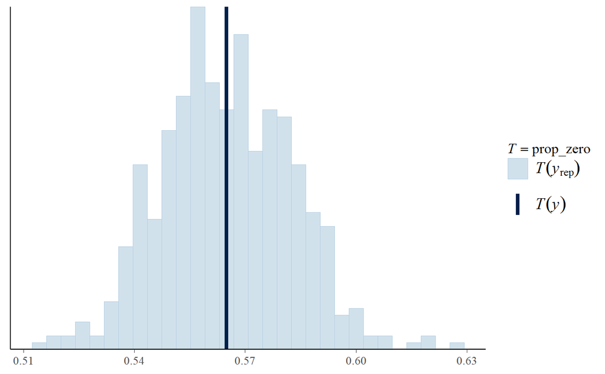

```r
prop_zero <- function(y) mean(y == 0)
pp_check(fit, plotfun = "stat", stat = "prop_zero")
```

```r
fit_loo = loo(fit)
fit_loo
```

```
##
## Computed from 500 by 1000 log-likelihood matrix
##
##          Estimate   SE
## elpd_loo  -1226.1 37.5
## p_loo        13.0  1.6
## looic      2452.1 75.0
## ------
## Monte Carlo SE of elpd_loo is 0.2.
##
## All Pareto k estimates are good (k < 0.5).
## See help('pareto-k-diagnostic') for details.
```

The above block shows the expected log predicted density (`elpd_loo`), estimate number of parameters (`p_loo`), and the LOO Information Criterion (`looic`) for a new dataset from Pareto smoothed importance-sampling leave-one-out (PSIS-LOO) cross-validation (CV). They can be used to check the goodness-of-fit of and compare different models (Vehtari, Gelman, and Gabry 2017, 2015). In a well-specified model, `p_loo` should be close to the total number of parameters. Similar to the Akaike information criterion (AIC) and Bayesian information criterion (BIC), the `looic` in the output can be used to compare different models, with lower values indicating better models.

```r
fit_new <- stan_glm(n_crash ~ sce_N + age + ping_speed,
                    offset = log(distance/1000),
                    data = stat[1:1000,], family = neg_binomial_2,
                    prior = normal(0,10),
                    prior_intercept = normal(0,10), QR = TRUE,
                    iter = 1000, chains = 1, cores = 1, seed = 123)
fit_new_loo = loo(fit_new)
```

```r
loo::compare(fit_loo, fit_new_loo)
```

```
## elpd_diff        se
##      -1.7       4.3
```

With two model fits `fit` and `fit_new` above, researchers can compare the model fit using `compare()` from the `loo` package, as shown above. It compares the expected predictive accuracy by the difference in `elpd_loo`, with positive difference `elpd_diff` suggesting the second model while negative difference favoring the first model.

# Reference

Vehtari, Aki, Andrew Gelman, and Jonah Gabry. 2015. “Pareto Smoothed Importance Sampling.” *arXiv Preprint arXiv:1507.02646*.

———. 2017. “Practical Bayesian Model Evaluation Using Leave-One-Out Cross-Validation and Waic.” *Statistics and Computing* 27 (5): 1413–32.